# Clustering Lab

```r
# optimal number appears to be 3


k_clust <- kmeans(metals_dat2,
                  centers = 3,
                  nstart = 25)

k_clust
```

```
## K-means clustering with 3 clusters of sizes 10, 22, 28
##
## Cluster means:
##         Cd       Cr        Cu        Mn    Ni
## 1 0.796000 6.530000 127.09000 126.28200 2.304
## 2 1.076818 6.180455  70.28455  66.79864 2.385
## 3 1.593214 3.462857  22.39893  18.85250 1.870
##
## Clustering vector:
##  [1] 2 2 1 1 1 1 3 2 2 2 2 2 2 2 1 2 2 1 3 3 3 3 3 3 3 3 2 2 2 2 3 3 3 3 3 3 1 3
## [39] 2 3 2 2 3 3 3 3 3 3 2 1 1 2 1 2 2 3 3 3 3 3
##
## Within cluster sum of squares by cluster:
## [1] 13159.695 22633.706  7511.094
##  (between_SS / total_SS =  80.4 %)
##
## Available components:
##
## [1] "cluster"      "centers"      "totss"        "withinss"     "tot.withinss"
## [6] "betweenss"    "size"         "iter"         "ifault"
```

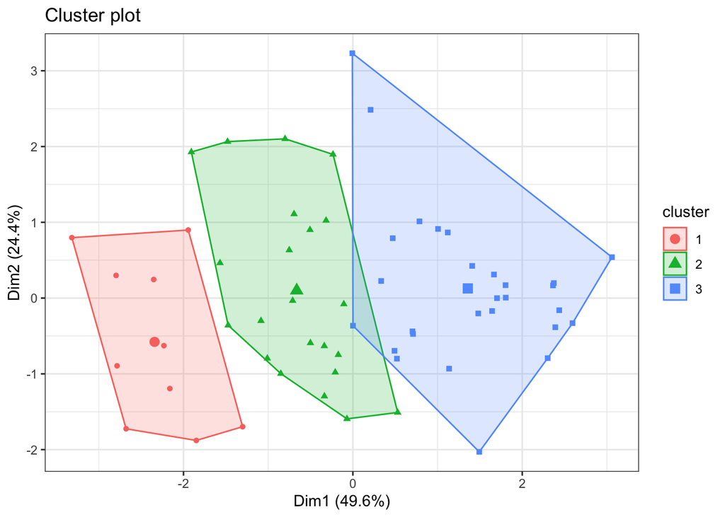

```r
metals_plot1 <- fviz_cluster(k_clust,
                             geom = "point",
                             data = metals_dat2) +
  theme_bw()

metals_plot1
```

Do you notice anything different about the spacing between clusters? Why might this be?

**The spacing between clusters seems slightly less tight / dense than in our previous dataset. This might be because there are varying levels of concentrations of metals at each of the 10 sample sites, and the levels might vary widely and overlap between the two types of algae which could lead to wider spacing in the clusters.**

Run summary() on your model object. Does anything stand out?

```r
summary(k_clust)
```

```
##              Length Class  Mode
## cluster      60     -none- numeric
## centers      15     -none- numeric
## totss         1     -none- numeric
## withinss      3     -none- numeric
## tot.withinss  1     -none- numeric
## betweenss     1     -none- numeric
## size          3     -none- numeric
## iter          1     -none- numeric
## ifault        1     -none- numeric
```

2. Good, now let’s move to hierarchical clustering that we saw in lecture. The first step for that is to calculate a distance matrix on the data (using dist()). Euclidean is a good choice for the distance method.

```r
distance <- dist(x = metals_dat2,
                 method = "euclidean")
```

3. Use tidy() on the distance matrix so you can see what is going on. What does each row in the resulting table represent?

```r
tidy(distance)
```

```
## # A tibble: 1,770 × 3
##    item1 item2 distance
##    <fct> <fct>    <dbl>
##  1 1     2         35.1
##  2 1     3         50.5
##  3 1     4         64.3
##  4 1     5         72.5
##  5 1     6         72.6
##  6 1     7        103.
##  7 1     8         11.4
##  8 1     9         22.4
##  9 1     10        45.1
## 10 1     11        23.3
## # ℹ 1,760 more rows
```

**Each row in the resulting table represents the distance between two points, beginning with the first data point and measuring the Euclidean distance between that point and all other points, and continuing on through all 60 data points.**

4. Then apply hierarchical clustering with hclust().

```r
h_clust <- hclust(distance)
h_clust
```

```
##
## Call:
## hclust(d = distance)
##
## Cluster method   : complete
## Distance         : euclidean
## Number of objects: 60
```

5. Now plot the clustering object. You can use something of the form plot(as.dendrogram()). Or you can check out the cool visual options here: https://rpubs.com/gaston/dendrograms

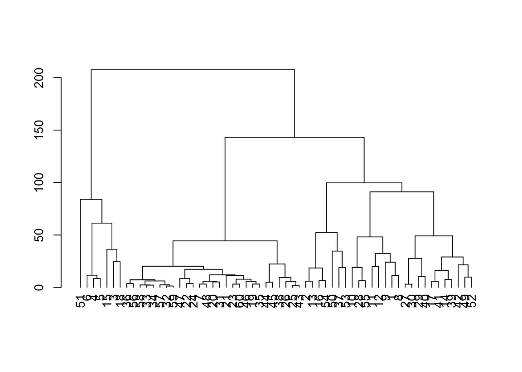

```r
plot(as.dendrogram(h_clust))
```

```r
# plot(h_clust)
```

How does the plot look? Do you see any outliers? How can you tell?